# Homework 02

Author

Prerith Arunkumar (prerith2)

Training versus test error, approximation bias and estimation variance, prediction at a single target point, the optimism correction, Mallows’ $C_p$, AIC, BIC, and honest validation.

```python
import numpy as np
import pandas as pd
import matplotlib.pyplot as plt

np.set_printoptions(precision=6, suppress=True)
pd.set_option("display.width", 120)
```

## Question 1 (Training and test error under a fixed design)

One matrix $\mathbf X_{\mathrm{all}} \in \mathbb R^{100 \times 20}$ with independent $N(0,1)$ entries is generated once and then held fixed. With $\beta_j = 0.4^{\sqrt j}$ for $j = 1, \ldots, 20$ and $\boldsymbol\mu = \mathbf X_{\mathrm{all}}\boldsymbol\beta$, each of the $200$ runs draws an independent training and test response,

$$\mathbf y = \boldsymbol\mu + \boldsymbol\epsilon, \qquad \mathbf y^* = \boldsymbol\mu + \boldsymbol\epsilon^*,
\qquad \boldsymbol\epsilon, \boldsymbol\epsilon^* \overset{\text{ind}}{\sim} N_n(\mathbf 0, \mathbf I_n).$$

For $m = 0, 1, \ldots, 20$ the model regresses $\mathbf y$ on an intercept and the first $m$ columns of $\mathbf X_{\mathrm{all}}$, giving $\widehat{\mathbf y}_m$, and

$$\operatorname{MSE}_{\mathrm{train},m} = \tfrac{1}{n}\lVert \mathbf y - \widehat{\mathbf y}_m \rVert_2^2,
\qquad
\operatorname{MSE}_{\mathrm{test},m} = \tfrac{1}{n}\lVert \mathbf y^* - \widehat{\mathbf y}_m \rVert_2^2.$$

Because $\boldsymbol\beta$ decays slowly — $\beta_1 = 0.400$ down to $\beta_{20} = 0.0166$ — no predictor is exactly useless, so this is a design where every added column reduces bias by a little and costs variance by a little.

### (a) Average training and test MSE over the 200 runs

```python
rng = np.random.default_rng(43202)

n, p, n_sim = 100, 20, 200

X_all = rng.normal(size=(n, p))                     # generated once, then held fixed
beta_true = 0.4 ** np.sqrt(np.arange(1, p + 1))     # beta_j = 0.4^sqrt(j)
mu = X_all @ beta_true                              # the fixed mean vector

def design(m):
    """Intercept plus the first m columns of X_all."""
    return np.column_stack([np.ones(n)] + ([X_all[:, :m]] if m else []))

mse_train = np.zeros((n_sim, p + 1))
mse_test = np.zeros((n_sim, p + 1))

for b in range(n_sim):
    y = mu + rng.normal(size=n)                     # training response
    y_star = mu + rng.normal(size=n)                # independent test response
    for m in range(p + 1):
        Xm = design(m)
        beta_hat, *_ = np.linalg.lstsq(Xm, y, rcond=None)
        fitted = Xm @ beta_hat
        mse_train[b, m] = np.mean((y - fitted) ** 2)
        mse_test[b, m] = np.mean((y_star - fitted) ** 2)

avg_train = mse_train.mean(axis=0)
avg_test = mse_test.mean(axis=0)

steps = np.diff(mse_train, axis=1)                  # change in training MSE for each m -> m+1
print(f"training MSE non-increasing in all {n_sim} runs: {bool(np.all(steps <= 1e-8))}")
print(f"largest observed increase over all runs and all steps: {steps.max():.3e}")
print(f"average training MSE: {avg_train[0]:.4f} at m = 0  ->  {avg_train[p]:.4f} at m = {p}")
print(f"average test MSE:     {avg_test[0]:.4f} at m = 0  ->  {avg_test[p]:.4f} at m = {p}")
print(f"average test MSE is minimized at m = {int(np.argmin(avg_test))}  (value {avg_test.min():.4f})")
```

```
training MSE non-increasing in all 200 runs: True
largest observed increase over all runs and all steps: -1.638e-09
average training MSE: 1.3220 at m = 0  ->  0.7889 at m = 20
average test MSE:     1.3416 at m = 0  ->  1.2119 at m = 20
average test MSE is minimized at m = 7  (value 1.1027)
```

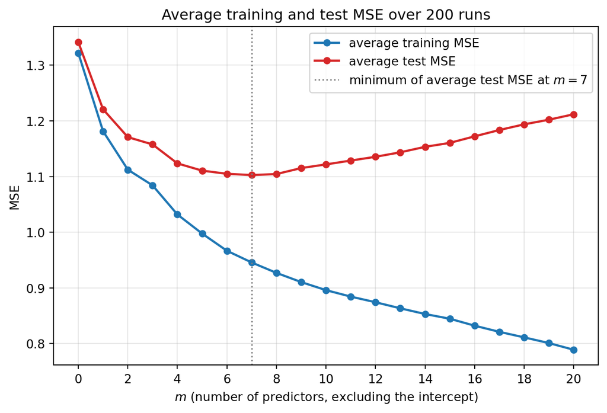

```python
m_grid = np.arange(p + 1)

fig, ax = plt.subplots(figsize=(8, 5))
ax.plot(m_grid, avg_train, "o-", color="#1f77b4", lw=1.8, ms=5, label="average training MSE")
ax.plot(m_grid, avg_test, "o-", color="#d62728", lw=1.8, ms=5, label="average test MSE")
ax.axvline(int(np.argmin(avg_test)), color="gray", ls=":", lw=1.2,
           label=f"minimum of average test MSE at $m = {int(np.argmin(avg_test))}$")
ax.set_xlabel("$m$ (number of predictors, excluding the intercept)")
ax.set_ylabel("MSE")
ax.set_title("Average training and test MSE over 200 runs")
ax.set_xticks(m_grid[::2])
ax.legend()
ax.grid(alpha=0.3)
plt.show()
```

**The two curves separate immediately.** Average training MSE falls monotonically from $1.3220$ at $m = 0$ to $0.7889$ at $m = 20$, dropping below the noise level $\sigma^2 = 1$ once $m \ge 5$. Average test MSE falls only until $m = 7$, where it reaches $1.1027$, and then rises steadily back to $1.2119$ at $m = 20$. The gap between them widens from $0.020$ at $m = 0$ to $0.423$ at $m = 20$, which is exactly the growing optimism of the training fit.

**Training MSE is non-increasing in every run, not merely on average.** The check above computes all $200 \times 20 = 4000$ increments $\operatorname{MSE}_{\mathrm{train},m+1} - \operatorname{MSE}_{\mathrm{train},m}$ and finds every one of them $\le 0$; the largest is $-1.6 \times 10^{-9}$, which is floating-point noise around an exact zero. This is not a property of this particular seed. The column space of $\mathbf X_m$ is nested inside that of $\mathbf X_{m+1}$, and $\widehat{\mathbf y}_m$ is the orthogonal projection of $\mathbf y$ onto that space, so $\lVert \mathbf y - \widehat{\mathbf y}_{m+1} \rVert_2^2$ is a minimum over a strictly larger set than $\lVert \mathbf y - \widehat{\mathbf y}_m \rVert_2^2$. Enlarging the feasible set of a minimization can never raise the minimum. The test curve carries no such guarantee, because $\widehat{\mathbf y}_m$ was never chosen to fit $\mathbf y^*$.

### (b) Theoretical expectations from the approximation bias

For each $m$ the total squared approximation bias is $B_m^2 = \lVert (\mathbf I_n - \mathbf H_m)\boldsymbol\mu \rVert_2^2$, the squared length of the part of $\boldsymbol\mu$ that the model cannot reach. It is computed below from the residual of $\boldsymbol\mu$ against $\mathbf X_m$ using a QR factorization, so $\mathbf H_m$ is never formed explicitly.

```python
B2 = np.zeros(p + 1)
for m in range(p + 1):
    Q, _ = np.linalg.qr(design(m))                  # orthonormal basis for the column space
    resid_mu = mu - Q @ (Q.T @ mu)                  # (I - H_m) mu
    B2[m] = resid_mu @ resid_mu

exp_train = B2 / n + 1 - (m_grid + 1) / n
exp_test = B2 / n + 1 + (m_grid + 1) / n

q1 = pd.DataFrame({
    "m": m_grid,
    "B_m^2 / n": B2 / n,
    "avg train": avg_train,
    "E(train)": exp_train,
    "avg test": avg_test,
    "E(test)": exp_test,
}).set_index("m")

print(f"max |average - theory|, training: {np.abs(avg_train - exp_train).max():.4f}")
print(f"max |average - theory|, test:     {np.abs(avg_test - exp_test).max():.4f}")
print(f"E(test) is minimized at m = {int(np.argmin(exp_test))}, matching the simulation average")
print(f"B_m^2 / n: {B2[0] / n:.4f} at m = 0  ->  {B2[p] / n:.3e} at m = {p}")
q1.round(4)
```

```
max |average - theory|, training: 0.0142
max |average - theory|, test:     0.0138
E(test) is minimized at m = 7, matching the simulation average
B_m^2 / n: 0.3178 at m = 0  ->  1.229e-31 at m = 20
```

| m | B_m^2 / n | avg train | E(train) | avg test | E(test) |
| --- | --- | --- | --- | --- | --- |
| 0 | 0.3178 | 1.3220 | 1.3078 | 1.3416 | 1.3278 |
| 1 | 0.1904 | 1.1815 | 1.1704 | 1.2208 | 1.2104 |
| 2 | 0.1324 | 1.1124 | 1.1024 | 1.1708 | 1.1624 |
| 3 | 0.1127 | 1.0842 | 1.0727 | 1.1577 | 1.1527 |
| 4 | 0.0716 | 1.0319 | 1.0216 | 1.1237 | 1.1216 |
| 5 | 0.0494 | 0.9976 | 0.9894 | 1.1107 | 1.1094 |
| 6 | 0.0327 | 0.9667 | 0.9627 | 1.1050 | 1.1027 |
| 7 | 0.0227 | 0.9457 | 0.9427 | 1.1027 | 1.1027 |
| 8 | 0.0154 | 0.9270 | 0.9254 | 1.1045 | 1.1054 |
| 9 | 0.0125 | 0.9105 | 0.9125 | 1.1153 | 1.1125 |
| 10 | 0.0080 | 0.8960 | 0.8980 | 1.1218 | 1.1180 |
| 11 | 0.0056 | 0.8844 | 0.8856 | 1.1287 | 1.1256 |
| 12 | 0.0044 | 0.8743 | 0.8744 | 1.1355 | 1.1344 |
| 13 | 0.0034 | 0.8634 | 0.8634 | 1.1436 | 1.1434 |
| 14 | 0.0026 | 0.8531 | 0.8526 | 1.1534 | 1.1526 |
| 15 | 0.0019 | 0.8446 | 0.8419 | 1.1605 | 1.1619 |
| 16 | 0.0013 | 0.8322 | 0.8313 | 1.1722 | 1.1713 |
| 17 | 0.0008 | 0.8211 | 0.8208 | 1.1836 | 1.1808 |
| 18 | 0.0004 | 0.8112 | 0.8104 | 1.1938 | 1.1904 |
| 19 | 0.0002 | 0.8009 | 0.8002 | 1.2021 | 1.2002 |
| 20 | 0.0000 | 0.7889 | 0.7900 | 1.2119 | 1.2100 |

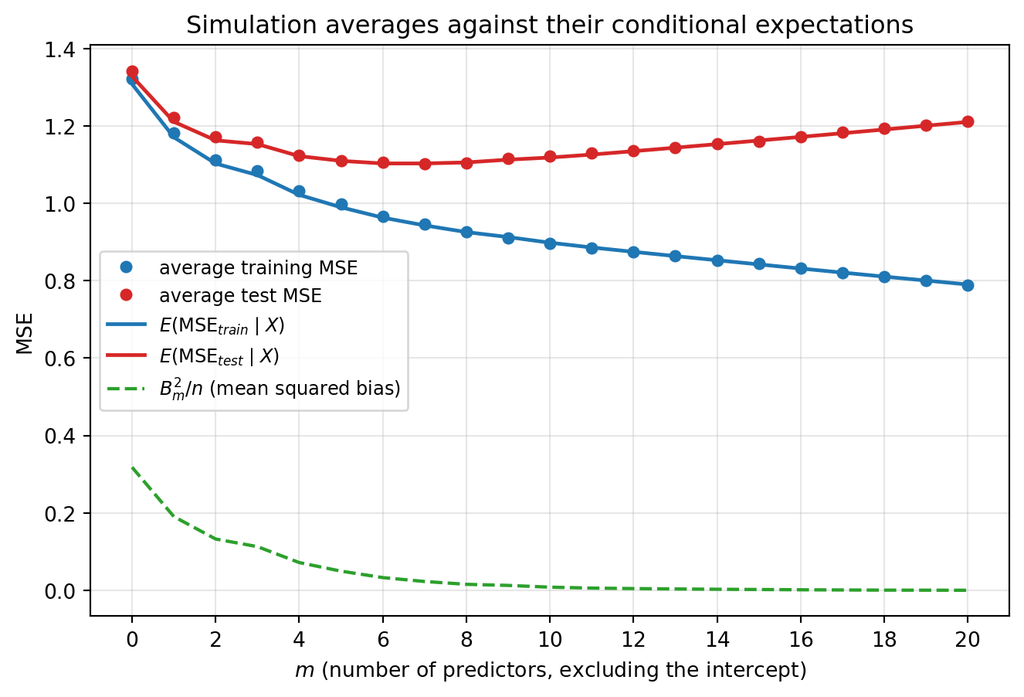

```python
fig, ax = plt.subplots(figsize=(8, 5))
ax.plot(m_grid, avg_train, "o", color="#1f77b4", ms=5, label="average training MSE")
ax.plot(m_grid, avg_test, "o", color="#d62728", ms=5, label="average test MSE")
ax.plot(m_grid, exp_train, "-", color="#1f77b4", lw=1.8, label=r"$E(\mathrm{MSE}_{train}\mid X)$")
ax.plot(m_grid, exp_test, "-", color="#d62728", lw=1.8, label=r"$E(\mathrm{MSE}_{test}\mid X)$")
ax.plot(m_grid, B2 / n, color="#2ca02c", lw=1.6, ls="--", label=r"$B_m^2/n$ (mean squared bias)")
ax.set_xlabel("$m$ (number of predictors, excluding the intercept)")
ax.set_ylabel("MSE")
ax.set_title("Simulation averages against their conditional expectations")
ax.set_xticks(m_grid[::2])
ax.legend(loc="center left", fontsize=9)
ax.grid(alpha=0.3)
plt.show()
```

**The averages sit on top of the theory.** The largest discrepancy across all $21$ values of $m$ is $0.0142$ for the training curve and $0.0138$ for the test curve, both well inside the Monte Carlo error of an average of $200$ draws (the run-to-run standard deviation of $\operatorname{MSE}_{\mathrm{test},m}$ runs between $0.154$ and $0.183$, so the standard error of the average is about $0.012$). The theoretical test curve is minimized at $m = 7$, the same $m$ the simulation average picks.

**The two expectations differ only in the sign of the complexity term.** Writing them side by side,

$$E(\operatorname{MSE}_{\mathrm{train},m} \mid \mathbf X_{\mathrm{all}}) = \frac{B_m^2}{n} + 1 - \frac{m+1}{n},
\qquad
E(\operatorname{MSE}_{\mathrm{test},m} \mid \mathbf X_{\mathrm{all}}) = \frac{B_m^2}{n} + 1 + \frac{m+1}{n},$$

the shared piece $B_m^2/n + 1$ is decreasing in $m$, and the term $(m+1)/n$ is increasing. In the training expectation the increasing term is *subtracted*, so both pieces push downward and the curve can only fall. In the test expectation it is *added*, so the curve is a genuine trade-off and has an interior minimum. The green dashed curve shows how fast the bias is spent: $B_m^2/n$ starts at $0.3178$, is already down to $0.0227$ by $m = 7$, and reaches $1.2 \times 10^{-31}$ at $m = 20$, where $\boldsymbol\mu$ lies exactly in the column space of the design. Past $m = 7$ there is essentially no bias left to buy, so each extra column adds $2/n = 0.02$ to the gap between the curves and buys almost nothing back.

### (c) A single run, and why training MSE cannot select $m$

```python
run1 = mse_test[0]
sd_test = mse_test.std(axis=0, ddof=1)
argmin_per_run = mse_test.argmin(axis=1)

print(f"run 1 test MSE is minimized at m = {int(np.argmin(run1))}  (value {run1.min():.4f})")
print(f"run 1 test MSE at the true optimum m = 7: {run1[7]:.4f}")
print(f"run 1 range (max - min): {run1.max() - run1.min():.4f}")
print(f"direction reversals along the run 1 curve: {int(np.sum(np.diff(np.sign(np.diff(run1))) != 0))}")
print(f"\nrun-to-run sd of MSE_test,m ranges over m from {sd_test.min():.4f} to {sd_test.max():.4f}")
print(f"standard error of the 200-run average:      {sd_test.mean() / np.sqrt(n_sim):.4f}")
print(f"\nruns whose test MSE is minimized at m = 7:  {int(np.sum(argmin_per_run == 7))} of {n_sim}")
print(f"runs whose minimizing m is anything else:  {int(np.sum(argmin_per_run != 7))} of {n_sim}"
      f"  ({100 * np.mean(argmin_per_run != 7):.1f}%)")
```

```
run 1 test MSE is minimized at m = 14  (value 0.7471)
run 1 test MSE at the true optimum m = 7: 0.8001
run 1 range (max - min): 0.3817
direction reversals along the run 1 curve: 11

run-to-run sd of MSE_test,m ranges over m from 0.1542 to 0.1827
standard error of the 200-run average:      0.0116

runs whose test MSE is minimized at m = 7:  23 of 200
runs whose minimizing m is anything else:  177 of 200  (88.5%)
```

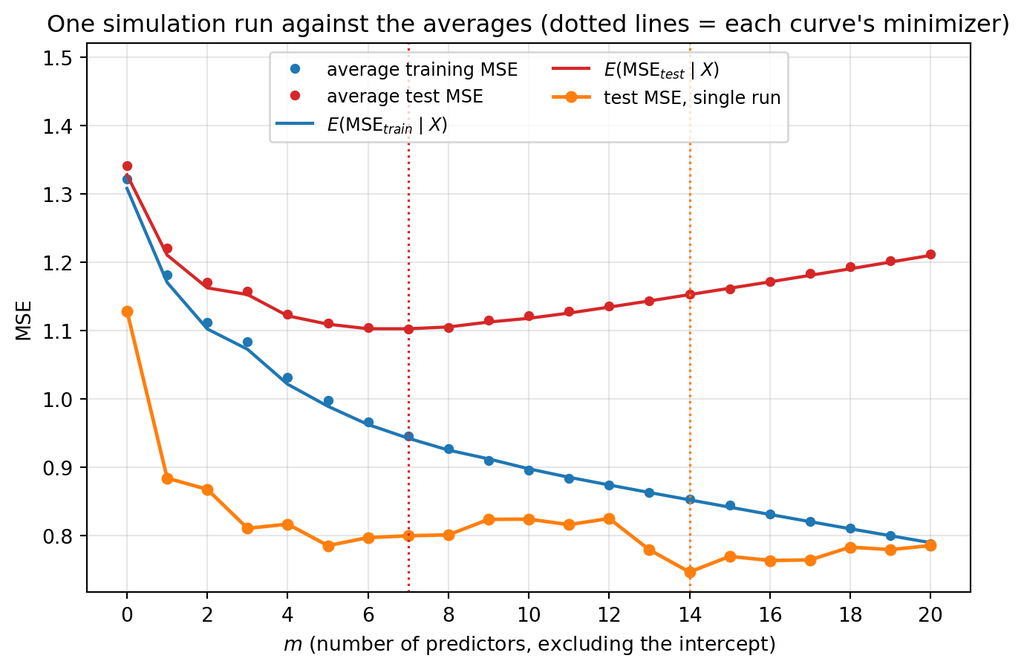

```python
fig, ax = plt.subplots(figsize=(8, 5))
ax.plot(m_grid, avg_train, "o", color="#1f77b4", ms=4, label="average training MSE")
ax.plot(m_grid, avg_test, "o", color="#d62728", ms=4, label="average test MSE")
ax.plot(m_grid, exp_train, "-", color="#1f77b4", lw=1.6, label=r"$E(\mathrm{MSE}_{train}\mid X)$")
ax.plot(m_grid, exp_test, "-", color="#d62728", lw=1.6, label=r"$E(\mathrm{MSE}_{test}\mid X)$")
ax.plot(m_grid, run1, "o-", color="#ff7f0e", lw=1.8, ms=5, label="test MSE, single run")
ax.axvline(7, color="#d62728", ls=":", lw=1.2)
ax.axvline(int(np.argmin(run1)), color="#ff7f0e", ls=":", lw=1.2)
ax.set_xlabel("$m$ (number of predictors, excluding the intercept)")
ax.set_ylabel("MSE")
ax.set_title("One simulation run against the averages (dotted lines = each curve's minimizer)")
ax.set_xticks(m_grid[::2])
ax.set_ylim(top=1.52)
ax.legend(loc="upper center", ncol=2, fontsize=9)
ax.grid(alpha=0.3)
plt.show()
```

**Why the single curve is rough.** The averaged curve is an estimate of $E(\operatorname{MSE}_{\mathrm{test},m} \mid \mathbf X_{\mathrm{all}})$ with Monte Carlo standard error about $0.012$; the single curve is one draw of a random variable whose standard deviation is between $0.154$ and $0.183$, roughly fourteen times larger. Averaging $200$ independent runs shrinks the noise by $\sqrt{200} \approx 14.1$, and what is left is the smooth systematic shape. The single run keeps all of it. Two things vary in a single run and neither is averaged away: the test noise $\boldsymbol\epsilon^*$, which is fixed across the whole curve and shifts it bodily up or down, and the training noise $\boldsymbol\epsilon$, which enters through $\widehat{\mathbf y}_m$ and changes with $m$. Adding column $m+1$ moves the fitted vector by the projection of $\mathbf y$ onto the part of $\mathbf x_{m+1}$ orthogonal to the previous columns. In one realization that step is sometimes lucky — the new direction happens to align with $\boldsymbol\mu$ and with $\boldsymbol\epsilon^*$ — and sometimes unlucky, so the curve wanders up and down instead of tracing a smooth U. Run 1 reverses direction $11$ times across the $20$ steps, spans $0.3817$ from its lowest to its highest point, and is minimized at $m = 14$ rather than $m = 7$. That is not unusual: only $23$ of the $200$ runs are minimized at the correct $m = 7$, and $88.5\%$ of them point somewhere else. Choosing $m$ from a single test set is itself a noisy procedure, a point taken up again in Question 5.

**Why training MSE alone cannot choose $m$.** Compare the two expectations term by term. Both contain the mean squared approximation bias $B_m^2/n$, which is non-increasing in $m$ and measures what the model structurally cannot represent. They differ in how they treat the estimation variance of the $m+1$ fitted coefficients, worth $\sigma^2(m+1)/n$:

$$E(\operatorname{MSE}_{\mathrm{train},m} \mid \mathbf X_{\mathrm{all}}) = \underbrace{\frac{B_m^2}{n}}_{\text{bias, decreasing}}
+ \sigma^2 \underbrace{\left(1 - \frac{m+1}{n}\right)}_{\text{also decreasing}},
\qquad
E(\operatorname{MSE}_{\mathrm{test},m} \mid \mathbf X_{\mathrm{all}}) = \underbrace{\frac{B_m^2}{n}}_{\text{bias, decreasing}}
+ \sigma^2 \underbrace{\left(1 + \frac{m+1}{n}\right)}_{\text{increasing}}.$$

Training MSE gives estimation variance the *wrong sign*. Fitting $m+1$ coefficients removes $m+1$ dimensions of the residual space, so the residual sum of squares is deflated by exactly the amount the extra parameters can absorb, and the training criterion is rewarded rather than penalized for spending them. Both of its terms therefore decrease in $m$, its minimizer is always $m = p$, and it would select the largest model available no matter how small the true coefficients were. The test expectation reverses that sign, so its minimizer sits where the marginal bias reduction $B_m^2/n - B_{m+1}^2/n$ stops exceeding the marginal variance cost $\sigma^2/n = 0.01$. In this simulation that crossing happens at $m = 7$: the bias drops by $0.0100$ going from $m = 6$ to $m = 7$, but only by $0.0073$ from $m = 7$ to $m = 8$. The difference between the two expectations is $2\sigma^2(m+1)/n$, the optimism, and it is exactly what Question 3 derives and what $C_p$ and AIC estimate.

## Question 2 (Prediction error at one target point)

Here $n = 100$, $p = 6$, $\sigma^2 = 1$, and the fixed design is the discrete cosine basis

$$(\mathbf X_{\mathrm{all}})_{ij} = \sqrt 2 \cos\!\left\{\frac{\pi j (i - \tfrac12)}{n}\right\},
\qquad \mathbf 1^{\mathsf T}\mathbf X_{\mathrm{all}} = \mathbf 0^{\mathsf T},
\qquad \tfrac{1}{n}\mathbf X_{\mathrm{all}}^{\mathsf T}\mathbf X_{\mathrm{all}} = \mathbf I_p.$$

With $\boldsymbol\beta = (0.5, \ldots, 0.5)^{\mathsf T}$ and $\mathbf y = \mathbf X_{\mathrm{all}}\boldsymbol\beta + \boldsymbol\epsilon$, the target is the mean response at $\mathbf x_0 = (0,1,0,0,1,0)^{\mathsf T}$, and

$$E\!\left[(\widehat\mu_{0,m} - \mu_0)^2 \mid \mathbf X_{\mathrm{all}}\right]
= \left(\sum_{j=m+1}^{p} x_{0j}\beta_j\right)^{\!2} + \frac{\sigma^2}{n}\left(1 + \sum_{j=1}^{m} x_{0j}^2\right).$$

### (a) $\mu_0$, the theoretical squared bias, and the expected squared error

```python
n2, p2 = 100, 6
i_idx = np.arange(1, n2 + 1)[:, None]
j_idx = np.arange(1, p2 + 1)[None, :]
X_all2 = np.sqrt(2) * np.cos(np.pi * j_idx * (i_idx - 0.5) / n2)

beta2 = np.full(p2, 0.5)
x0 = np.array([0.0, 1.0, 0.0, 0.0, 1.0, 0.0])
sigma2 = 1.0
mu0 = x0 @ beta2

print(f"max |1' X_all|                 = {np.abs(X_all2.sum(axis=0)).max():.3e}   (columns are centered)")
print(f"max |X_all' X_all / n - I_p|   = {np.abs(X_all2.T @ X_all2 / n2 - np.eye(p2)).max():.3e}   (columns are orthonormal)")
print(f"mu0 = x0' beta = {mu0:.4f}")

m_grid2 = np.arange(p2 + 1)
sq_bias = np.array([(x0[m:] * beta2[m:]).sum() ** 2 for m in m_grid2])
variance = np.array([sigma2 / n2 * (1 + (x0[:m] ** 2).sum()) for m in m_grid2])
exp_sq_err = sq_bias + variance

q2a = pd.DataFrame({
    "m": m_grid2,
    "predictor added": ["-"] + [f"x{j}" for j in range(1, p2 + 1)],
    "x_{0m}": ["-"] + list(x0),
    "squared bias": sq_bias,
    "variance": variance,
    "E[(mu0_hat - mu0)^2]": exp_sq_err,
}).set_index("m")
q2a.round(4)
```

```
max |1' X_all|                 = 1.532e-14   (columns are centered)
max |X_all' X_all / n - I_p|   = 4.441e-16   (columns are orthonormal)
mu0 = x0' beta = 1.0000
```

| m | predictor added | x_{0m} | squared bias | variance | E[(mu0_hat - mu0)^2] |
| --- | --- | --- | --- | --- | --- |
| 0 | - | - | 1.00 | 0.01 | 1.01 |
| 1 | x1 | 0.0 | 1.00 | 0.01 | 1.01 |
| 2 | x2 | 1.0 | 0.25 | 0.02 | 0.27 |
| 3 | x3 | 0.0 | 0.25 | 0.02 | 0.27 |
| 4 | x4 | 0.0 | 0.25 | 0.02 | 0.27 |
| 5 | x5 | 1.0 | 0.00 | 0.03 | 0.03 |
| 6 | x6 | 0.0 | 0.00 | 0.03 | 0.03 |

**The target value.** Since $\mathbf x_0$ selects coordinates $2$ and $5$, $\mu_0 = \beta_2 + \beta_5 = 0.5 + 0.5 = 1$.

**Why the formula splits into these two pieces.** The prediction is $\widehat\mu_{0,m} = \widehat\beta_0 + \sum_{j=1}^{m} x_{0j}\widehat\beta_j$, and it misses $\mu_0$ for two separate reasons. The first is structural: predictors $m+1, \ldots, p$ are simply not in the model, so their contribution $\sum_{j>m} x_{0j}\beta_j$ to the true mean is unrepresented no matter how much data is collected. Because the design is orthogonal, dropping those columns does not distort the coefficients that remain — $\widehat\beta_j$ for $j \le m$ is unbiased for $\beta_j$ — so the entire structural error is that omitted sum, and squaring it gives the first term. It is a fixed number, not a random one. The second reason is that the $m+1$ coefficients that *are* in the model must be estimated from noisy data. With $\tfrac{1}{n}\mathbf X^{\mathsf T}\mathbf X = \mathbf I_p$ and centered columns the estimates are uncorrelated with variance $\sigma^2/n$ each, so the variance of the linear combination $\widehat\beta_0 + \sum_{j \le m} x_{0j}\widehat\beta_j$ is $(\sigma^2/n)(1 + \sum_{j \le m} x_{0j}^2)$: one unit for the intercept, plus $x_{0j}^2$ for each fitted slope. That is the second term. Bias is what the model cannot say; variance is the price of the questions it does ask.

**Where the expected error changes and where it does not.** It changes only at $m = 2$ and $m = 5$, falling from $1.0100$ to $0.2700$ and then to $0.0300$. It is unchanged at $m = 1$, $m = 3$, $m = 4$, and $m = 6$. The reason is that every quantity in the formula is weighted by $x_{0j}$, and $x_{01} = x_{03} = x_{04} = x_{06} = 0$. Adding predictor $1$, $3$, $4$, or $6$ contributes nothing to the bias sum, because $x_{0j}\beta_j = 0$, and nothing to the variance sum, because $x_{0j}^2 = 0$. In an orthogonal design the new coefficient is estimated without perturbing the others, so the prediction at $\mathbf x_0$ is *numerically identical* before and after — such a predictor is free but also worthless for this target. Adding predictor $2$ removes $(0.5)^2$ of bias for $0.01$ of variance, and adding predictor $5$ removes the remaining $(0.5)^2$ for another $0.01$; both are overwhelmingly worth it.

### (b) Simulation against theory

```python
rng2 = np.random.default_rng(43203)

sq_err = np.zeros((n_sim, p2 + 1))
for b in range(n_sim):
    y2 = X_all2 @ beta2 + rng2.normal(size=n2)
    for m in range(p2 + 1):
        Xm = np.column_stack([np.ones(n2)] + ([X_all2[:, :m]] if m else []))
        beta_hat, *_ = np.linalg.lstsq(Xm, y2, rcond=None)
        pred = beta_hat[0] + (x0[:m] @ beta_hat[1:] if m else 0.0)
        sq_err[b, m] = (pred - mu0) ** 2

avg_sq_err = sq_err.mean(axis=0)
m_star = int(np.argmin(exp_sq_err))

q2b = pd.DataFrame({
    "m": m_grid2,
    "squared bias": sq_bias,
    "variance": variance,
    "E[(mu0_hat - mu0)^2]": exp_sq_err,
    "simulation average": avg_sq_err,
    "MC std. error": sq_err.std(axis=0, ddof=1) / np.sqrt(n_sim),
}).set_index("m")

print(f"smallest m minimizing the theoretical error: m = {m_star}  (value {exp_sq_err[m_star]:.4f})")
print(f"the simulation average is also flat from m = {m_star} onward: "
      f"{avg_sq_err[m_star]:.4f} at m = {m_star}, {avg_sq_err[p2]:.4f} at m = {p2}")
print(f"identical columns of results, as predicted: "
      f"m=0,1 agree to {np.abs(avg_sq_err[0] - avg_sq_err[1]):.1e}; "
      f"m=2,3,4 to {np.abs(avg_sq_err[2:5] - avg_sq_err[2]).max():.1e}; "
      f"m=5,6 to {np.abs(avg_sq_err[5] - avg_sq_err[6]):.1e}")
q2b.round(4)
```

```
smallest m minimizing the theoretical error: m = 5  (value 0.0300)
the simulation average is also flat from m = 5 onward: 0.0237 at m = 5, 0.0237 at m = 6
identical columns of results, as predicted: m=0,1 agree to 0.0e+00; m=2,3,4 to 1.7e-16; m=5,6 to 6.9e-17
```

| m | squared bias | variance | E[(mu0_hat - mu0)^2] | simulation average | MC std. error |
| --- | --- | --- | --- | --- | --- |
| 0 | 1.00 | 0.01 | 1.01 | 0.9839 | 0.0128 |
| 1 | 1.00 | 0.01 | 1.01 | 0.9839 | 0.0128 |
| 2 | 0.25 | 0.02 | 0.27 | 0.2464 | 0.0084 |
| 3 | 0.25 | 0.02 | 0.27 | 0.2464 | 0.0084 |
| 4 | 0.25 | 0.02 | 0.27 | 0.2464 | 0.0084 |
| 5 | 0.00 | 0.03 | 0.03 | 0.0237 | 0.0022 |
| 6 | 0.00 | 0.03 | 0.03 | 0.0237 | 0.0022 |

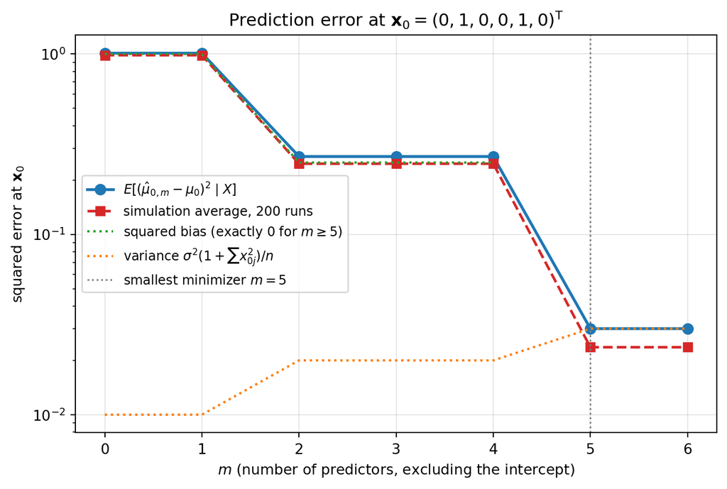

```python
fig, ax = plt.subplots(figsize=(8, 5))
ax.plot(m_grid2, exp_sq_err, "o-", color="#1f77b4", lw=2, ms=7, label=r"$E[(\hat\mu_{0,m}-\mu_0)^2\mid X]$")
ax.plot(m_grid2, avg_sq_err, "s--", color="#d62728", lw=1.8, ms=6, label="simulation average, 200 runs")
sq_bias_pos = np.where(sq_bias > 0, sq_bias, np.nan)   # zero cannot be drawn on a log axis
ax.plot(m_grid2, sq_bias_pos, color="#2ca02c", lw=1.6, ls=":", label=r"squared bias (exactly $0$ for $m \geq 5$)")
ax.plot(m_grid2, variance, color="#ff7f0e", lw=1.6, ls=":", label=r"variance $\sigma^2(1+\sum x_{0j}^2)/n$")
ax.axvline(m_star, color="gray", ls=":", lw=1.2, label=f"smallest minimizer $m = {m_star}$")
ax.set_xlabel("$m$ (number of predictors, excluding the intercept)")
ax.set_ylabel(r"squared error at $\mathbf{x}_0$")
ax.set_title(r"Prediction error at $\mathbf{x}_0 = (0,1,0,0,1,0)^{\mathsf{T}}$")
ax.set_yscale("log")
ax.set_xticks(m_grid2)
ax.legend(fontsize=9)
ax.grid(alpha=0.3)
plt.show()
```

**The simulation reproduces the staircase.** The averages track the theory closely and, more tellingly, reproduce its flat stretches exactly rather than approximately: the simulated averages at $m = 0$ and $m = 1$ agree to machine precision, as do those at $m = 2, 3, 4$ and those at $m = 5, 6$. This is stronger than the theory strictly requires. The theory says the *expectations* are equal; the simulation shows the realized predictions are literally the same numbers, because in an orthogonal design adding a column with $x_{0j} = 0$ leaves $\widehat\mu_{0,m}$ untouched in every draw.

The averages run a little below the theoretical values — $0.9839$ against $1.0100$ at $m = 0$, $0.2464$ against $0.2700$ at $m = 2$, $0.0237$ against $0.0300$ at $m = 5$. Each gap is about two Monte Carlo standard errors, and the three are not independent evidence of a problem: the same $200$ draws of $\widehat\beta_0$, $\widehat\beta_2$ and $\widehat\beta_5$ enter every row of the table, so this is one shared fluctuation showing up seven times rather than seven separate ones. It is ordinary sampling variability, not a systematic disagreement. The plot uses a logarithmic vertical axis because the error falls by a factor of more than $30$ across the range, which a linear axis would flatten into invisibility past $m = 2$.

**The smallest minimizer is $m = 5$.** The theoretical error is $0.0300$ at both $m = 5$ and $m = 6$, and the question asks for the smallest such $m$. Note that the target-specific optimum here is *not* the full model: predictor $6$ is genuinely nonzero, but it is invisible at $\mathbf x_0$, so including it neither helps nor hurts.

### (c) Why only predictors 2 and 5 matter here

```python
# For this design the row-averaged squared bias is B_m^2 / n = sum_{j>m} beta_j^2, since the
# columns are orthonormal. Compare it with the bias at the single target point x0.
B2_rows = np.array([n2 * (beta2[m:] ** 2).sum() for m in m_grid2]) / n2
exp_test_rows = B2_rows + sigma2 * (1 + (m_grid2 + 1) / n2)

pd.DataFrame({
    "m": m_grid2,
    "bias^2 at x0": sq_bias,
    "bias^2 averaged over rows": B2_rows,
    "E(test MSE) over rows": exp_test_rows,
    "E(sq. error) at x0": exp_sq_err,
}).set_index("m").round(4)
```

| m | bias^2 at x0 | bias^2 averaged over rows | E(test MSE) over rows | E(sq. error) at x0 |
| --- | --- | --- | --- | --- |
| 0 | 1.00 | 1.50 | 2.51 | 1.01 |
| 1 | 1.00 | 1.25 | 2.27 | 1.01 |
| 2 | 0.25 | 1.00 | 2.03 | 0.27 |
| 3 | 0.25 | 0.75 | 1.79 | 0.27 |
| 4 | 0.25 | 0.50 | 1.55 | 0.27 |
| 5 | 0.00 | 0.25 | 1.31 | 0.03 |
| 6 | 0.00 | 0.00 | 1.07 | 0.03 |

**Only coordinates $2$ and $5$ of $\mathbf x_0$ are nonzero.** The quantity being predicted is the linear functional $\mu_0 = \mathbf x_0^{\mathsf T}\boldsymbol\beta = \sum_{j=1}^{6} x_{0j}\beta_j$, and each coefficient enters that sum multiplied by its own coordinate of the target point. With $\mathbf x_0 = (0,1,0,0,1,0)^{\mathsf T}$ the products $x_{01}\beta_1$, $x_{03}\beta_3$, $x_{04}\beta_4$, $x_{06}\beta_6$ are all $0 \cdot 0.5 = 0$. That $\beta_6 \ne 0$ is a statement about how the response moves when $x_6$ moves; at this particular point $x_6$ sits at zero, so its slope has nothing to act on. The same coefficients would matter a great deal at a target point with $x_{06} \ne 0$. Relevance is a property of the pair (coefficient, query point), not of the coefficient alone.

There is also no *indirect* contribution, and that is a consequence of the orthogonal design rather than of the target. Because $\tfrac{1}{n}\mathbf X_{\mathrm{all}}^{\mathsf T}\mathbf X_{\mathrm{all}} = \mathbf I_p$, omitting column $6$ leaves $\widehat\beta_2$ and $\widehat\beta_5$ exactly unbiased and numerically unchanged. In a correlated design the omitted-variable bias of $\widehat\beta_2$ would depend on $\beta_6$ and on the correlation between $\mathbf x_2$ and $\mathbf x_6$, so predictor $6$ would leak into the prediction at $\mathbf x_0$ even though $x_{06} = 0$.

**Contrast with the test MSE of Question 1.** The two criteria measure different things, and the table above shows how far apart they land on the same data. Question 1 uses

$$\operatorname{MSE}_{\mathrm{test},m} = \frac{1}{n}\sum_{i=1}^{n}\left(y_i^* - \widehat\mu_{i,m}\right)^2,$$

which differs from the target-specific criterion in two ways. First, it *averages over all $n$ rows* of $\mathbf X_{\mathrm{all}}$, so it aggregates the squared bias at $100$ different query points into $B_m^2/n = \tfrac{1}{n}\sum_i \{(\mathbf I_n - \mathbf H_m)\boldsymbol\mu\}_i^2$. A predictor that is invisible at one particular point is almost never invisible on average: for this design the row-averaged squared bias falls by $\beta_j^2 = 0.25$ at *every* step, from $1.50$ at $m = 0$ to $0$ at $m = 6$, with no flat stretches at all, while the bias at $\mathbf x_0$ is flat at $m = 1, 3, 4$. Second, it predicts a new *observation* $y_i^*$ rather than the mean $\mu_0$, so it carries the irreducible noise $\sigma^2 = 1$ that no model can remove. That constant floor dominates: the row-averaged expected test MSE never drops below $1.07$, whereas the error at $\mathbf x_0$ reaches $0.03$.

The practical consequence is that the two criteria select differently. Averaged over rows, every column pays for itself here — the bias saving $0.25$ dwarfs the variance cost $\sigma^2/n = 0.01$ — so the row-averaged criterion is minimized at the full model $m = 6$. At $\mathbf x_0$ the smallest minimizer is $m = 5$, and predictors $1$, $3$, and $4$ could be dropped with no penalty at all. A model chosen to minimize average prediction error is not necessarily the model one would choose to predict at a particular point of interest, and reporting “the best model” without naming the target is incomplete.

## Question 3 (The optimism correction)

A single candidate model is fixed before the response is seen, with full-rank design $\mathbf X \in \mathbb R^{n \times (p+1)}$, hat matrix $\mathbf H = \mathbf X(\mathbf X^{\mathsf T}\mathbf X)^{-1}\mathbf X^{\mathsf T}$, and $\mathbf y = \boldsymbol\mu + \boldsymbol\epsilon$, $\mathbf y^* = \boldsymbol\mu + \boldsymbol\epsilon^*$ with $\boldsymbol\epsilon \perp \boldsymbol\epsilon^*$, $E\boldsymbol\epsilon = \mathbf 0$, and $\operatorname{Cov}(\boldsymbol\epsilon \mid \mathbf X) = \sigma^2\mathbf I_n$. Throughout, $\mathbf H^{\mathsf T} = \mathbf H$, $\mathbf H^2 = \mathbf H$, $\operatorname{tr}(\mathbf H) = p+1$, and $B^2 = \lVert (\mathbf I_n - \mathbf H)\boldsymbol\mu \rVert_2^2$. All expectations below are conditional on $\mathbf X$.

### (a) Deriving the two expectations

**Training MSE.** Since $\mathbf y - \mathbf H\mathbf y = (\mathbf I_n - \mathbf H)\mathbf y$ and $\mathbf y = \boldsymbol\mu + \boldsymbol\epsilon$, linearity of $\mathbf I_n - \mathbf H$ gives the decomposition

$$(\mathbf I_n - \mathbf H)\mathbf y = \underbrace{(\mathbf I_n - \mathbf H)\boldsymbol\mu}_{\text{fixed}}
+ \underbrace{(\mathbf I_n - \mathbf H)\boldsymbol\epsilon}_{\text{random, mean } \mathbf 0}.$$

Expanding the squared norm of a sum,

$$n\operatorname{MSE}_{\mathrm{train}} = \lVert(\mathbf I_n - \mathbf H)\boldsymbol\mu\rVert_2^2
+ 2\boldsymbol\mu^{\mathsf T}(\mathbf I_n - \mathbf H)^{\mathsf T}(\mathbf I_n - \mathbf H)\boldsymbol\epsilon
+ \lVert(\mathbf I_n - \mathbf H)\boldsymbol\epsilon\rVert_2^2.$$

Take expectations term by term. The first term is the constant $B^2$. The middle term is linear in $\boldsymbol\epsilon$ with a fixed coefficient vector, so its expectation is $0$ because $E(\boldsymbol\epsilon \mid \mathbf X) = \mathbf 0$. For the third, note that $\mathbf I_n - \mathbf H$ is symmetric and idempotent — $(\mathbf I_n - \mathbf H)^{\mathsf T}(\mathbf I_n - \mathbf H) = \mathbf I_n - 2\mathbf H + \mathbf H^2 = \mathbf I_n - \mathbf H$ — so it is a quadratic form in $\boldsymbol\epsilon$ with matrix $\mathbf I_n - \mathbf H$, and the trace identity gives

$$E\!\left(\lVert(\mathbf I_n - \mathbf H)\boldsymbol\epsilon\rVert_2^2 \mid \mathbf X\right)
= E\!\left(\boldsymbol\epsilon^{\mathsf T}(\mathbf I_n - \mathbf H)\boldsymbol\epsilon \mid \mathbf X\right)
= \sigma^2\operatorname{tr}(\mathbf I_n - \mathbf H) = \sigma^2\{n - (p+1)\}.$$

Dividing by $n$,

$$E(\operatorname{MSE}_{\mathrm{train}} \mid \mathbf X) = \frac{B^2}{n} + \sigma^2\left(1 - \frac{p+1}{n}\right).$$

**Test MSE.** Now $\mathbf y^* - \mathbf H\mathbf y = \boldsymbol\mu + \boldsymbol\epsilon^* - \mathbf H(\boldsymbol\mu + \boldsymbol\epsilon)$, which separates into three pieces,

$$\mathbf y^* - \mathbf H\mathbf y = \underbrace{(\mathbf I_n - \mathbf H)\boldsymbol\mu}_{\text{fixed}}
+ \underbrace{\boldsymbol\epsilon^*}_{\text{test noise}} - \underbrace{\mathbf H\boldsymbol\epsilon}_{\text{estimation noise}}.$$

Expanding the squared norm produces three squared terms and three cross terms:

$$n\operatorname{MSE}_{\mathrm{test}} = B^2 + \lVert\boldsymbol\epsilon^*\rVert_2^2 + \lVert\mathbf H\boldsymbol\epsilon\rVert_2^2
+ 2\boldsymbol\mu^{\mathsf T}(\mathbf I_n - \mathbf H)\boldsymbol\epsilon^*
- 2\boldsymbol\mu^{\mathsf T}(\mathbf I_n - \mathbf H)\mathbf H\boldsymbol\epsilon
- 2\boldsymbol\epsilon^{*\mathsf T}\mathbf H\boldsymbol\epsilon.$$

The two cross terms involving $\boldsymbol\mu$ are linear in a mean-zero error vector, so both vanish in expectation. (The second vanishes for a further reason: $(\mathbf I_n - \mathbf H)\mathbf H = \mathbf H - \mathbf H^2 = \mathbf 0$.) The final cross term vanishes because $\boldsymbol\epsilon^*$ and $\boldsymbol\epsilon$ are independent and mean zero, so $E(\boldsymbol\epsilon^{*\mathsf T}\mathbf H\boldsymbol\epsilon \mid \mathbf X) = E(\boldsymbol\epsilon^* \mid \mathbf X)^{\mathsf T}\mathbf H\,E(\boldsymbol\epsilon \mid \mathbf X) = 0$. For the squared terms, $E\lVert\boldsymbol\epsilon^*\rVert_2^2 = \sigma^2\operatorname{tr}(\mathbf I_n) = n\sigma^2$, and since $\mathbf H^{\mathsf T}\mathbf H = \mathbf H^2 = \mathbf H$,

$$E\!\left(\lVert\mathbf H\boldsymbol\epsilon\rVert_2^2 \mid \mathbf X\right)
= E\!\left(\boldsymbol\epsilon^{\mathsf T}\mathbf H\boldsymbol\epsilon \mid \mathbf X\right)
= \sigma^2\operatorname{tr}(\mathbf H) = \sigma^2(p+1).$$

Collecting and dividing by $n$,

$$E(\operatorname{MSE}_{\mathrm{test}} \mid \mathbf X) = \frac{B^2}{n} + \sigma^2\left(1 + \frac{p+1}{n}\right).$$

The asymmetry has a clean source. In the training expectation the fitted vector is *correlated* with the very noise it is scored against, and projecting removes $p+1$ dimensions of that noise, giving $\operatorname{tr}(\mathbf I_n - \mathbf H) = n - (p+1)$. In the test expectation the score is against fresh noise, so the full $n\sigma^2$ survives and the estimation noise $\lVert\mathbf H\boldsymbol\epsilon\rVert_2^2$ is *added* on top rather than subtracted, contributing $\operatorname{tr}(\mathbf H) = p+1$.

### (b) The expected optimism

Subtracting the two results, the bias term $B^2/n$ appears in both and cancels exactly:

$$E(\operatorname{MSE}_{\mathrm{test}} - \operatorname{MSE}_{\mathrm{train}} \mid \mathbf X)
= \sigma^2\left(1 + \frac{p+1}{n}\right) - \sigma^2\left(1 - \frac{p+1}{n}\right)
= \frac{2\sigma^2(p+1)}{n}.$$

The expected optimism does not depend on $\boldsymbol\mu$ at all. It depends only on the noise level, the sample size, and the number of fitted coefficients — which is precisely what makes it estimable, and hence correctable, without knowing the truth.

```python
n3, p3, b2_over_n, sigma2_3 = 120, 4, 0.04, 1.0

e_train_3 = b2_over_n + sigma2_3 * (1 - (p3 + 1) / n3)
e_test_3 = b2_over_n + sigma2_3 * (1 + (p3 + 1) / n3)
optimism = 2 * sigma2_3 * (p3 + 1) / n3

print(f"E(MSE_train | X) = {b2_over_n} + {sigma2_3} * (1 - {p3 + 1}/{n3}) = {e_train_3:.6f}")
print(f"E(MSE_test  | X) = {b2_over_n} + {sigma2_3} * (1 + {p3 + 1}/{n3}) = {e_test_3:.6f}")
print(f"expected optimism = 2 * {sigma2_3} * {p3 + 1} / {n3}            = {optimism:.6f}")
print(f"check: E(test) - E(train) = {e_test_3 - e_train_3:.6f}")
```

```
E(MSE_train | X) = 0.04 + 1.0 * (1 - 5/120) = 0.998333
E(MSE_test  | X) = 0.04 + 1.0 * (1 + 5/120) = 1.081667
expected optimism = 2 * 1.0 * 5 / 120            = 0.083333
check: E(test) - E(train) = 0.083333
```

```python
# A direct check, and a look at how often the ordering fails in a single realized pair.
rng3 = np.random.default_rng(43204)

X3 = np.column_stack([np.ones(n3), rng3.normal(size=(n3, p3))])
Q3, _ = np.linalg.qr(X3)

v = rng3.normal(size=n3)
v -= Q3 @ (Q3.T @ v)                                # push v into the orthogonal complement of col(X)
v /= np.linalg.norm(v)
mu3 = X3 @ np.arange(1.0, p3 + 2) + np.sqrt(n3 * b2_over_n) * v   # so that B^2 / n is exactly 0.04

resid_mu3 = mu3 - Q3 @ (Q3.T @ mu3)
print(f"realized B^2 / n = {resid_mu3 @ resid_mu3 / n3:.6f}   (target {b2_over_n})")

n_rep = 20000
tr3 = np.empty(n_rep)
te3 = np.empty(n_rep)
for b in range(n_rep):
    eps = rng3.normal(scale=np.sqrt(sigma2_3), size=n3)
    eps_star = rng3.normal(scale=np.sqrt(sigma2_3), size=n3)
    y3 = mu3 + eps
    fitted3 = Q3 @ (Q3.T @ y3)
    tr3[b] = np.mean((y3 - fitted3) ** 2)
    te3[b] = np.mean((mu3 + eps_star - fitted3) ** 2)

print(f"\nsimulated E(MSE_train) = {tr3.mean():.6f}   theory {e_train_3:.6f}")
print(f"simulated E(MSE_test)  = {te3.mean():.6f}   theory {e_test_3:.6f}")
print(f"simulated optimism     = {te3.mean() - tr3.mean():.6f}   theory {optimism:.6f}")
print(f"\nsd of the realized difference MSE_test - MSE_train: {np.std(te3 - tr3, ddof=1):.4f}")
print(f"fraction of pairs with MSE_test < MSE_train:        {np.mean(te3 < tr3):.4f}")
```

```
realized B^2 / n = 0.040000   (target 0.04)

simulated E(MSE_train) = 0.997164   theory 0.998333
simulated E(MSE_test)  = 1.080709   theory 1.081667
simulated optimism     = 0.083545   theory 0.083333

sd of the realized difference MSE_test - MSE_train: 0.1928
fraction of pairs with MSE_test < MSE_train:        0.3338
```

**The numbers.** With $n = 120$, $p = 4$, $B^2/n = 0.04$ and $\sigma^2 = 1$, the model fits $p + 1 = 5$ coefficients, so $(p+1)/n = 5/120 = 0.041\overline{6}$ and

$$E(\operatorname{MSE}_{\mathrm{train}}) = 0.04 + 0.958333 = 0.998333, \qquad
E(\operatorname{MSE}_{\mathrm{test}}) = 0.04 + 1.041667 = 1.081667, \qquad
\text{optimism} = \tfrac{10}{120} = 0.083333.$$

The simulation reproduces all three to within Monte Carlo error over $20{,}000$ replications. Note how misleading the training figure is as a noise estimate: $\operatorname{MSE}_{\mathrm{train}}$ averages $0.998$, which sits almost exactly at $\sigma^2 = 1$ and so looks like an unbiased estimate of the noise, but that agreement is a coincidence of two errors cancelling — the bias $+0.04$ and the degrees-of-freedom deflation $-0.0417$. The honest out-of-sample figure is $8.3\%$ higher.

**Why the ordering can fail in a realized pair.** The inequality $E(\operatorname{MSE}_{\mathrm{test}}) > E(\operatorname{MSE}_{\mathrm{train}})$ is a statement about averages over repeated draws of $(\boldsymbol\epsilon, \boldsymbol\epsilon^*)$, not about any single pair of response vectors. The realized difference

$$\operatorname{MSE}_{\mathrm{test}} - \operatorname{MSE}_{\mathrm{train}}
= \frac{1}{n}\left(\lVert\boldsymbol\epsilon^*\rVert_2^2 - \lVert\boldsymbol\epsilon\rVert_2^2\right) + \cdots$$

is a random variable, and its leading term is a difference of two independent noise magnitudes. Its standard deviation is about $0.193$ here, more than twice its mean of $0.0833$, so the difference is negative whenever the test draw happens to be quieter than the training draw by enough to overcome the systematic gap. The simulation finds $\operatorname{MSE}_{\mathrm{test}} < \operatorname{MSE}_{\mathrm{train}}$ in $33.4\%$ of the $20{,}000$ pairs. With $n = 120$ and only $5$ coefficients the systematic optimism is small relative to the sampling noise, so a single comparison is nearly uninformative — which is the practical reason for correcting the training error analytically, as in part (c), rather than reading one train/test comparison as evidence.

### (c) The corrected test MSE and $C_p$

```python
RSS, sigma2_hat = 116.4, 0.96

mse_test_hat = (RSS + 2 * (p3 + 1) * sigma2_hat) / n3
Cp = RSS / sigma2_hat - n3 + 2 * (p3 + 1)

print(f"training MSE = RSS / n                       = {RSS / n3:.6f}")
print(f"optimism correction = 2 (p+1) sigma2_hat / n = {2 * (p3 + 1) * sigma2_hat / n3:.6f}")
print(f"MSE_test_hat = (RSS + 2 (p+1) sigma2_hat)/n  = {mse_test_hat:.6f}")
print(f"Cp = RSS / sigma2_hat - n + 2 (p+1)          = {Cp:.6f}")
print(f"\ncheck  MSE_test_hat = sigma2_hat (Cp + n) / n = {sigma2_hat * (Cp + n3) / n3:.6f}")
print(f"check  Cp = n * MSE_test_hat / sigma2_hat - n = {n3 * mse_test_hat / sigma2_hat - n3:.6f}")
```

```
training MSE = RSS / n                       = 0.970000
optimism correction = 2 (p+1) sigma2_hat / n = 0.080000
MSE_test_hat = (RSS + 2 (p+1) sigma2_hat)/n  = 1.050000
Cp = RSS / sigma2_hat - n + 2 (p+1)          = 11.250000

check  MSE_test_hat = sigma2_hat (Cp + n) / n = 1.050000
check  Cp = n * MSE_test_hat / sigma2_hat - n = 11.250000
```

**The two quantities are the same statistic on two scales.** Multiply $\widehat{\operatorname{MSE}}_{\mathrm{test}}$ by $n/\widehat\sigma^2$:

$$\frac{n}{\widehat\sigma^2}\widehat{\operatorname{MSE}}_{\mathrm{test}}
= \frac{\operatorname{RSS} + 2(p+1)\widehat\sigma^2}{\widehat\sigma^2}
= \frac{\operatorname{RSS}}{\widehat\sigma^2} + 2(p+1)
= C_p + n,$$

so the exact relationship is

$$C_p = \frac{n}{\widehat\sigma^2}\widehat{\operatorname{MSE}}_{\mathrm{test}} - n,
\qquad\text{equivalently}\qquad
\widehat{\operatorname{MSE}}_{\mathrm{test}} = \frac{\widehat\sigma^2}{n}C_p + \widehat\sigma^2.$$

With the given numbers, $\widehat{\operatorname{MSE}}_{\mathrm{test}} = (116.4 + 9.6)/120 = 126/120 = 1.05$ and $C_p = 121.25 - 120 + 10 = 11.25$, and indeed $(0.96/120)(11.25) + 0.96 = 0.09 + 0.96 = 1.05$. The interpretation is worth stating explicitly: the raw training MSE is $\operatorname{RSS}/n = 0.97$, and the correction adds $2(p+1)\widehat\sigma^2/n = 0.08$ — exactly the plug-in estimate of the optimism derived in part (b) — to reach $1.05$.

**Why minimizing either gives the same choice.** The second display expresses $\widehat{\operatorname{MSE}}_{\mathrm{test}}$ as an affine function $a\,C_p + b$ with slope $a = \widehat\sigma^2/n > 0$ and intercept $b = \widehat\sigma^2$. When $n$ and $\widehat\sigma^2$ are held common across all candidate models — as they are when $\widehat\sigma^2$ comes once from a single full reference model fitted on the same $n$ rows — both $a$ and $b$ are the same constants for every candidate. A strictly increasing affine transformation preserves order, so for any two candidates,

$$C_p^{(1)} < C_p^{(2)}
\iff \widehat{\operatorname{MSE}}_{\mathrm{test}}^{(1)} < \widehat{\operatorname{MSE}}_{\mathrm{test}}^{(2)},$$

and the two criteria produce identical rankings and identical minimizers. They differ only in units and offset: $C_p$ is measured in units of $\widehat\sigma^2$ and shifted so that a correctly specified model has $C_p \approx p + 1$, while $\widehat{\operatorname{MSE}}_{\mathrm{test}}$ is measured in the squared units of the response and is directly readable as a prediction error. The equivalence fails the moment $\widehat\sigma^2$ is re-estimated separately within each candidate model, since then the slope and intercept vary across candidates.

## Question 4 (Comparing Mallows’ $C_p$, AIC, and BIC)

Rows $1$ through $370$ of `diabetes.csv` are the training data, so $n = 370$; rows $371$ through $442$ are set aside entirely and are not touched until Question 5. Three models are fitted with an intercept:

| Model | Predictors | $p$ |
| --- | --- | --- |
| Model A | `bmi`, `bp`, `s5`, `sex`, `s1`, `s2`, `s4` | 7 |
| Model B | Model A plus `s6` | 8 |
| Full reference | all ten predictors | 10 |

One common noise variance is estimated from the full reference model, $\widehat\sigma^2 = \operatorname{RSS}_{\mathrm{full}} / \{n - (p+1)\}$ with $p = 10$, and is then held fixed for both candidates.

### (a) The three fits, $\widehat\sigma^2$, and the residual degrees of freedom

```python
diabetes = pd.read_csv("data/diabetes.csv")
train = diabetes.iloc[:370]
test = diabetes.iloc[370:]

all_predictors = ["age", "sex", "bmi", "bp", "s1", "s2", "s3", "s4", "s5", "s6"]
model_A = ["bmi", "bp", "s5", "sex", "s1", "s2", "s4"]
model_B = model_A + ["s6"]

print("dimensions (rows, columns):", diabetes.shape)
print("columns:", list(diabetes.columns))
print(f"training rows 1-370: n = {len(train)};  final test rows 371-442: {len(test)}")
print("missing values:", int(diabetes.isna().sum().sum()))

def fit_ols(cols, data):
    """Least-squares fit of y on an intercept plus cols; returns coefficients and RSS."""
    X = np.column_stack([np.ones(len(data))] + [data[c].to_numpy() for c in cols])
    y = data["y"].to_numpy()
    beta_hat, *_ = np.linalg.lstsq(X, y, rcond=None)
    r = y - X @ beta_hat
    return beta_hat, r @ r

n4 = len(train)
_, rss_A = fit_ols(model_A, train)
_, rss_B = fit_ols(model_B, train)
_, rss_full = fit_ols(all_predictors, train)

df_full = n4 - (10 + 1)
sigma2_hat_4 = rss_full / df_full

print(f"\nRSS, model A (p =  7): {rss_A:14.4f}")
print(f"RSS, model B (p =  8): {rss_B:14.4f}")
print(f"RSS, full     (p = 10): {rss_full:14.4f}")
print(f"\nresidual degrees of freedom of the full model: n - (p+1) = {n4} - 11 = {df_full}")
print(f"sigma2_hat = RSS_full / {df_full} = {sigma2_hat_4:.4f}   (sigma_hat = {np.sqrt(sigma2_hat_4):.4f})")
```

```
dimensions (rows, columns): (442, 11)
columns: ['age', 'sex', 'bmi', 'bp', 's1', 's2', 's3', 's4', 's5', 's6', 'y']
training rows 1-370: n = 370;  final test rows 371-442: 72
missing values: 0

RSS, model A (p =  7):   1098908.5656
RSS, model B (p =  8):   1089717.0568
RSS, full     (p = 10):   1089451.7212

residual degrees of freedom of the full model: n - (p+1) = 370 - 11 = 359
sigma2_hat = RSS_full / 359 = 3034.6845   (sigma_hat = 55.0880)
```

**The fits.** All three models are fitted on the same $370$ rows with an intercept, and the data have no missing values, so the comparison is not disturbed by differing sample sizes. The residual sums of squares are $1{,}098{,}908.57$ for Model A ($p = 7$), $1{,}089{,}717.06$ for Model B ($p = 8$), and $1{,}089{,}451.72$ for the full reference model ($p = 10$). The full model has $n - (p+1) = 370 - 11 = 359$ residual degrees of freedom, giving

$$\widehat\sigma^2 = \frac{1{,}089{,}451.72}{359} = 3034.6845, \qquad \widehat\sigma = 55.088.$$

The response ranges from $25$ to $346$ with a standard deviation near $77$, so a residual standard deviation of $55$ is a substantial but not implausible reduction. Two details are worth noting before the criteria are computed. First, Model B is nested inside the full model but Model A and Model B are themselves nested, which is what makes the one-parameter comparison in part (c) clean. Second, the two predictors in the full model but not in Model B — `age` and `s3` — together reduce the RSS by only $265.34$, so $\widehat\sigma^2$ taken from the full model is close to what Model B itself would give; the reference model is not doing anything unusual here.

It matters that this single $\widehat\sigma^2$ is then held fixed across both candidates. The full reference model serves no other purpose in this question — it is not a candidate and is never selected — and its only job is to supply one common noise estimate. Re-estimating $\widehat\sigma^2$ separately within each candidate would change the $C_p$ comparison, and not in a harmless way: each model’s own $\operatorname{RSS}/\{n-(p+1)\}$ is inflated by whatever bias that model carries, so a badly underfitting candidate would be judged against a correspondingly forgiving yardstick and its $C_p$ would be pulled toward $p+1$ regardless of how poor it is. The whole point of $C_p$ is to measure each candidate’s RSS against a yardstick it did not choose, which is also why the argument of Question 3(c) — that minimizing $C_p$ and minimizing $\widehat{\operatorname{MSE}}_{\mathrm{test}}$ agree — required $n$ and $\widehat\sigma^2$ to be common to all candidates.

### (b) $C_p$, reduced AIC, and reduced BIC

```python
rows = []
for name, cols, rss in [("Model A", model_A, rss_A), ("Model B", model_B, rss_B)]:
    p_m = len(cols)
    rows.append({
        "model": name,
        "p": p_m,
        "p + 1": p_m + 1,
        "RSS": rss,
        "Cp": rss / sigma2_hat_4 - n4 + 2 * (p_m + 1),
        "AIC_red": n4 * np.log(rss / n4) + 2 * (p_m + 1),
        "BIC_red": n4 * np.log(rss / n4) + (p_m + 1) * np.log(n4),
    })
crit = pd.DataFrame(rows).set_index("model")

for c in ["Cp", "AIC_red", "BIC_red"]:
    winner = crit[c].idxmin()
    print(f"{c:8s}: A = {crit.loc['Model A', c]:11.4f},  B = {crit.loc['Model B', c]:11.4f}"
          f"   ->  selects {winner}  (difference {abs(crit.loc['Model A', c] - crit.loc['Model B', c]):.4f})")

crit.round(4)
```

```
Cp      : A =      8.1163,  B =      7.0874   ->  selects Model B  (difference 1.0288)
AIC_red : A =   2974.6403,  B =   2973.5325   ->  selects Model B  (difference 1.1078)
BIC_red : A =   3005.9483,  B =   3008.7540   ->  selects Model A  (difference 2.8057)
```

| model | p | p + 1 | RSS | Cp | AIC_red | BIC_red |
| --- | --- | --- | --- | --- | --- | --- |
| Model A | 7 | 8 | 1.098909e+06 | 8.1163 | 2974.6403 | 3005.9483 |
| Model B | 8 | 9 | 1.089717e+06 | 7.0874 | 2973.5325 | 3008.7540 |

**What each criterion selects.**

- $C_p$: $8.1163$ for Model A against $7.0874$ for Model B, so **$C_p$ selects Model B**.
- Reduced AIC: $2974.6403$ against $2973.5325$, so **AIC selects Model B**.
- Reduced BIC: $3005.9483$ against $3008.7540$, so **BIC selects Model A**.

Two of the three prefer the larger model and one prefers the smaller. As the question instructs, no comparison is made *across* criteria: the $C_p$ values near $7$–$8$ and the AIC and BIC values near $3000$ live on entirely different scales (the reduced AIC and BIC drop the additive constant $n + n\log(2\pi)$ common to both candidates, and $C_p$ is additionally divided by $\widehat\sigma^2$), so only the within-column ordering carries meaning. It is also worth noting that $C_p \approx p + 1$ would be expected for an adequately specified model; Model A has $C_p = 8.12$ against $p + 1 = 8$, and Model B has $C_p = 7.09$ against $p + 1 = 9$, so neither shows evidence of serious underfitting relative to the full reference.

### (c) The improvement from `s6` against each penalty

```python
delta_rss = rss_A - rss_B

gain_Cp = delta_rss / sigma2_hat_4                              # fit gain on the Cp scale
gain_aic = n4 * np.log(rss_A / n4) - n4 * np.log(rss_B / n4)    # fit gain on the log-likelihood scale
pen_aic = 2.0
pen_bic = np.log(n4)

print(f"RSS reduction from adding s6: {delta_rss:.4f}   "
      f"({100 * delta_rss / rss_A:.3f}% of RSS_A)")
print(f"implied |t| statistic for s6: sqrt({gain_Cp:.4f}) = {np.sqrt(gain_Cp):.4f}\n")
print(f"{'criterion':10s}{'fit gain':>12s}{'penalty':>12s}{'net change':>14s}{'adds s6?':>12s}")
print(f"{'Cp':10s}{gain_Cp:12.4f}{2.0:12.4f}{2.0 - gain_Cp:14.4f}{'yes' if gain_Cp > 2 else 'no':>12s}")
print(f"{'AIC':10s}{gain_aic:12.4f}{pen_aic:12.4f}{pen_aic - gain_aic:14.4f}{'yes' if gain_aic > pen_aic else 'no':>12s}")
print(f"{'BIC':10s}{gain_aic:12.4f}{pen_bic:12.4f}{pen_bic - gain_aic:14.4f}{'yes' if gain_aic > pen_bic else 'no':>12s}")
print(f"\ninclusion thresholds on the |t| scale: Cp and AIC need |t| > sqrt(2) = {np.sqrt(2):.4f}, "
      f"BIC needs |t| > sqrt(log n) = {np.sqrt(pen_bic):.4f}")
```

```
RSS reduction from adding s6: 9191.5089   (0.836% of RSS_A)
implied |t| statistic for s6: sqrt(3.0288) = 1.7404

criterion     fit gain     penalty    net change    adds s6?
Cp              3.0288      2.0000       -1.0288         yes
AIC             3.1078      2.0000       -1.1078         yes
BIC             3.1078      5.9135        2.8057          no

inclusion thresholds on the |t| scale: Cp and AIC need |t| > sqrt(2) = 1.4142, BIC needs |t| > sqrt(log n) = 2.4318
```

**One improvement, three different prices.** Adding `s6` lowers the residual sum of squares by $9{,}191.51$, which is $0.836\%$ of Model A’s RSS. Each criterion converts that improvement into its own currency and compares it against a one-parameter penalty:

| Criterion | Fit gain from `s6` | Penalty for one parameter | Net change | Decision |
| --- | --- | --- | --- | --- |
| $C_p$ | $\Delta\operatorname{RSS}/\widehat\sigma^2 = 3.0288$ | $2$ | $-1.0288$ | add `s6` |
| $\operatorname{AIC}^{\mathrm{red}}$ | $n\log(\operatorname{RSS}_A/\operatorname{RSS}_B) = 3.1078$ | $2$ | $-1.1078$ | add `s6` |
| $\operatorname{BIC}^{\mathrm{red}}$ | $n\log(\operatorname{RSS}_A/\operatorname{RSS}_B) = 3.1078$ | $\log 370 = 5.9135$ | $+2.8057$ | keep Model A |

These net changes reproduce the differences computed above exactly: $C_p$ falls by $1.03$, reduced AIC falls by $1.11$, and reduced BIC rises by $2.81$. The $C_p$ and AIC gains differ slightly ($3.03$ against $3.11$) only because $C_p$ measures fit on a linear RSS scale using an externally supplied $\widehat\sigma^2$ while AIC measures it on a logarithmic scale using each model’s own RSS; the two agree to first order and here differ by $0.08$.

**Where the disagreement comes from.** It comes entirely from the penalty column, not from any disagreement about the data. $C_p$ and AIC both charge $2$ per parameter, because both target expected prediction error and $2\sigma^2(p+1)/n$ is exactly the optimism derived in Question 3(b). BIC charges $\log n = \log 370 = 5.91$, nearly three times as much, because it targets a different question — which model is most likely to be the true one — and that penalty grows with $n$ so that the criterion is consistent for the true model when it is among the candidates. On the $t$-statistic scale the three thresholds are transparent: $C_p$ and AIC add a predictor when its $|t| > \sqrt 2 = 1.414$, BIC when $|t| > \sqrt{\log n} = 2.432$. The coefficient on `s6` has $|t| = 1.740$. It lands squarely in the gap, so the disagreement is not a numerical accident but the expected outcome for a predictor of exactly this marginal strength. A $|t|$ of $1.74$ corresponds to a two-sided $p$-value near $0.08$, so `s6` is not significant at the conventional $5\%$ level either — it is a genuinely borderline predictor, and criteria with different penalties are *supposed* to split on borderline cases.

**Why selection is not identification.** Nothing in this exercise establishes that the selected model is the true data-generating model, for several reasons that compound.

1. **The criteria answer a different question.** $C_p$ and AIC estimate out-of-sample squared prediction error. A model can predict well while being structurally wrong — omitting a real predictor whose signal is carried by a correlated one, or including a predictor that proxies for something unmeasured. Minimizing estimated prediction error selects a useful approximation, not a causal or structural truth.
2. **The comparison is confined to the candidate list.** Only two models were compared here, both linear, additive, and homoscedastic in the ten recorded variables. If the true relationship involves an interaction, a nonlinearity, or a variable that was never measured, then every candidate is wrong and the criteria can only report which wrong model is least bad. “Best of the list” carries no guarantee about anything off the list.
3. **The criteria are themselves random.** $C_p$, AIC, and BIC are statistics computed from one sample of $370$ rows, so they have sampling variability. The margins here are small — $1.03$ on the $C_p$ scale, $1.11$ on the AIC scale — comfortably within what a different draw of $370$ patients could reverse. A margin that thin is a weak preference, not a finding.
4. **The disagreement is itself evidence of fragility.** Two reasonable criteria applied to the same numbers reach opposite conclusions. If the evidence for `s6` were strong, all three would agree. The honest summary is that the data are close to indifferent about `s6`, and that a report should say so rather than present one criterion’s verdict as the answer.

## Question 5 (Validation and final test data)

Rows $1$–$370$ are the training data and rows $371$–$442$ are the final test data. Eleven nested candidates are indexed by $m = 0, 1, \ldots, 10$, where model $m$ contains an intercept and the first $m$ of

`age`, `sex`, `bmi`, `bp`, `s1`, `s2`, `s3`, `s4`, `s5`, `s6`.

The analyst proposes: (1) fit all eleven on the training data; (2) compute each model’s MSE on the final test data; (3) select the model with the smallest test MSE; (4) report that minimum as the final estimate of prediction error. The defence offered is that the final test data were never used to estimate regression coefficients.

### (a) The first misuse, and why the minimum is too favorable

```python
def train_and_test_mse(cols):
    beta_hat, rss = fit_ols(cols, train)
    X_te = np.column_stack([np.ones(len(test))] + [test[c].to_numpy() for c in cols])
    y_te = test["y"].to_numpy()
    return rss / len(train), np.mean((y_te - X_te @ beta_hat) ** 2)

m_grid5 = np.arange(11)
train_mse5 = np.zeros(11)
test_mse5 = np.zeros(11)
for m in m_grid5:
    train_mse5[m], test_mse5[m] = train_and_test_mse(all_predictors[:m])

m_hat_test = int(np.argmin(test_mse5))

q5a = pd.DataFrame({
    "m": m_grid5,
    "predictor added": ["(intercept only)"] + all_predictors,
    "training MSE": train_mse5,
    "final test MSE": test_mse5,
}).set_index("m")

print(f"the analyst's procedure selects m = {m_hat_test} and reports {test_mse5.min():.4f}")
print(f"second best: m = {int(np.argsort(test_mse5)[1])} at {np.sort(test_mse5)[1]:.4f}"
      f"   (margin {np.sort(test_mse5)[1] - test_mse5.min():.4f})")
q5a.round(4)
```

```
the analyst's procedure selects m = 9 and reports 2369.3445
second best: m = 10 at 2484.7759   (margin 115.4314)
```

| m | predictor added | training MSE | final test MSE |
| --- | --- | --- | --- |
| 0 | (intercept only) | 5951.9301 | 5822.8901 |
| 1 | age | 5759.7198 | 5527.7912 |
| 2 | sex | 5759.7162 | 5527.2097 |
| 3 | bmi | 3878.6552 | 3719.2351 |
| 4 | bp | 3620.5164 | 3246.8232 |
| 5 | s1 | 3618.0662 | 3234.9186 |
| 6 | s2 | 3610.0960 | 3207.6146 |
| 7 | s3 | 3080.7026 | 2636.5025 |
| 8 | s4 | 3078.2005 | 2624.9245 |
| 9 | s5 | 2967.9241 | 2369.3445 |
| 10 | s6 | 2944.4641 | 2484.7759 |

**Step 2 is the first misuse.** Step 1 is unobjectionable: fitting eleven models on rows $1$–$370$ uses only the training data and is exactly what should happen. The violation begins at step 2, where the eleven MSEs are calculated on the final test data. It is tempting to argue that merely computing a number cannot be a misuse and that only the selection at step 3 does any harm, but that defence fails on two counts. First, step 2 exists in this procedure solely to feed step 3: the eleven values are computed for the express purpose of comparing candidates, so the final test responses enter the model-selection pipeline the moment they are evaluated, whatever happens next. Second, the damage is done by *looking*, not by any formal act of choosing. Once the analyst has seen all eleven numbers the knowledge cannot be discarded, and every subsequent decision is conditioned on the test responses — including a decision to keep the model that would have been chosen anyway.

Steps 3 and 4 then complete the damage rather than initiate it. Step 3 makes the dependence explicit, turning an evaluation set into a selection set, because the identity of the chosen model now depends on the test responses. Step 4 reports a number computed on the same data that drove the choice, presenting a selection statistic as though it were an independent evaluation.

The analyst’s defence — that the test responses never entered the estimation of $\widehat{\boldsymbol\beta}$ — is too narrow. It treats “using the data” as synonymous with “fitting coefficients,” but a selection rule is part of the modelling procedure just as much as least squares is. The full procedure being evaluated is *“fit eleven models, then pick the one that does best on rows 371–442,”* and this procedure has seen every one of those test responses. Only data untouched by any step of the procedure — estimation and selection alike — can give an unbiased assessment of it.

**Why the minimum of eleven values is too favorable.** Each test MSE is a noisy estimate of the corresponding model’s true prediction error, computed on only $72$ observations. Write $T_m = \theta_m + e_m$, where $\theta_m$ is the true error and $e_m$ is estimation noise. Taking a minimum over $m$ selects on the *sum*, so it favours models with small $\theta_m$ *and* models that drew a favourably negative $e_m$. By Jensen’s inequality applied to the minimum, which is a concave function of its arguments,

$$E\!\left(\min_m T_m\right) \;\le\; \min_m E(T_m) = \min_m \theta_m,$$

so the reported minimum is downward biased for the best achievable error, and biased still further for the error of the *selected* model, since the winner is the one whose noise was most helpful. The bias grows with the number of candidates compared and with the noise in each estimate; here eleven candidates are compared using $72$ test rows, so both factors are unfavourable. The margin makes the point concretely: the winner at $m = 9$ scores $2369.34$ and the runner-up at $m = 10$ scores $2484.78$, a gap of $115.43$ that is small relative to the sampling variability of an MSE computed on $72$ points. The ordering between those two is close to a coin flip, but the reported number keeps only the luckier of the two. And there is no way to repair the estimate after the fact, because the test set has been spent.

### (b) The analysis rewritten with five-fold cross-validation

```python
rng5 = np.random.default_rng(43204)
n_folds = 5
fold_id = np.array_split(rng5.permutation(n4), n_folds)     # random partition of the 370 training rows

cv_mse = np.zeros(11)
for m in m_grid5:
    cols = all_predictors[:m]
    fold_errors = np.zeros(n_folds)
    for k in range(n_folds):
        valid_rows = fold_id[k]
        fit_rows = np.setdiff1d(np.arange(n4), valid_rows)
        d_fit, d_valid = train.iloc[fit_rows], train.iloc[valid_rows]
        beta_hat, _ = fit_ols(cols, d_fit)                  # coefficients from the 4 training folds only
        X_valid = np.column_stack([np.ones(len(d_valid))] + [d_valid[c].to_numpy() for c in cols])
        fold_errors[k] = np.mean((d_valid["y"].to_numpy() - X_valid @ beta_hat) ** 2)
    cv_mse[m] = fold_errors.mean()

m_star5 = int(np.argmin(cv_mse))
beta_final, _ = fit_ols(all_predictors[:m_star5], train)    # refit on all 370 training rows
_, honest_test_mse = train_and_test_mse(all_predictors[:m_star5])

print(f"five-fold CV selects m = {m_star5}"
      f"  (predictors: {', '.join(all_predictors[:m_star5]) if m_star5 else 'intercept only'})")
print(f"CV estimate at the selected m:            {cv_mse[m_star5]:.4f}")
print(f"honest final test MSE, used exactly once: {honest_test_mse:.4f}")
print(f"\nthe analyst's reported minimum:           {test_mse5.min():.4f}  (at m = {m_hat_test})")
print(f"optimism of the analyst's number:         {honest_test_mse - test_mse5.min():.4f}"
      f"   ({100 * (honest_test_mse - test_mse5.min()) / honest_test_mse:.1f}% of the honest figure)")

pd.DataFrame({
    "m": m_grid5,
    "training MSE": train_mse5,
    "5-fold CV MSE": cv_mse,
    "final test MSE (not used for selection)": test_mse5,
}).set_index("m").round(4)
```

```
five-fold CV selects m = 10  (predictors: age, sex, bmi, bp, s1, s2, s3, s4, s5, s6)
CV estimate at the selected m:            3215.4302
honest final test MSE, used exactly once: 2484.7759

the analyst's reported minimum:           2369.3445  (at m = 9)
optimism of the analyst's number:         115.4314   (4.6% of the honest figure)
```

| m | training MSE | 5-fold CV MSE | final test MSE (not used for selection) |
| --- | --- | --- | --- |
| 0 | 5951.9301 | 5998.3343 | 5822.8901 |
| 1 | 5759.7198 | 5837.1838 | 5527.7912 |
| 2 | 5759.7162 | 5872.0704 | 5527.2097 |
| 3 | 3878.6552 | 3962.4241 | 3719.2351 |
| 4 | 3620.5164 | 3742.2479 | 3246.8232 |
| 5 | 3618.0662 | 3769.3018 | 3234.9186 |
| 6 | 3610.0960 | 3787.9139 | 3207.6146 |
| 7 | 3080.7026 | 3342.9670 | 2636.5025 |
| 8 | 3078.2005 | 3370.5699 | 2624.9245 |
| 9 | 2967.9241 | 3241.0691 | 2369.3445 |
| 10 | 2944.4641 | 3215.4302 | 2484.7759 |

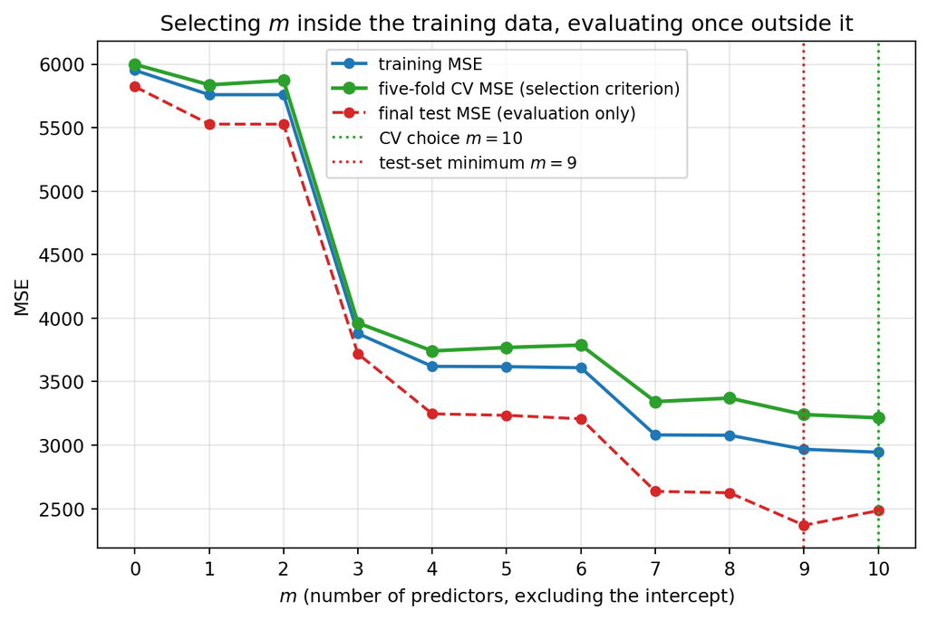

```python
fig, ax = plt.subplots(figsize=(8, 5))
ax.plot(m_grid5, train_mse5, "o-", color="#1f77b4", lw=1.8, ms=5, label="training MSE")
ax.plot(m_grid5, cv_mse, "o-", color="#2ca02c", lw=2, ms=6, label="five-fold CV MSE (selection criterion)")
ax.plot(m_grid5, test_mse5, "o--", color="#d62728", lw=1.6, ms=5, label="final test MSE (evaluation only)")
ax.axvline(m_star5, color="#2ca02c", ls=":", lw=1.4, label=f"CV choice $m = {m_star5}$")
ax.axvline(m_hat_test, color="#d62728", ls=":", lw=1.4, label=f"test-set minimum $m = {m_hat_test}$")
ax.set_xlabel("$m$ (number of predictors, excluding the intercept)")
ax.set_ylabel("MSE")
ax.set_title("Selecting $m$ inside the training data, evaluating once outside it")
ax.set_xticks(m_grid5)
ax.legend(fontsize=9)
ax.grid(alpha=0.3)
plt.show()
```

**The corrected procedure.** Every decision moves inside the training data, and the final test data are held back until a single pre-committed evaluation.

1. **Partition.** Split the $370$ training rows at random into five folds of roughly $74$ rows each. The final test rows $371$–$442$ take no part in this and are not looked at.
2. **Cross-validate.** For each $m = 0, \ldots, 10$ and each fold $k = 1, \ldots, 5$, fit the model with the first $m$ predictors on the other four folds only, predict the held-out fold, and record its mean squared error. Average the five fold errors to obtain $\operatorname{CV}_5(m)$. Every row is used for validation exactly once and for fitting four times, and no row ever validates a model that was fitted using it.
3. **Select the predictor count.** Choose $m^\star = \arg\min_m \operatorname{CV}_5(m)$. This is the only place the predictor count is decided, and it uses training data only.
4. **Refit.** Refit the model with the first $m^\star$ predictors on **all $370$ training rows**, not on any subset. The fold-specific fits were a device for estimating error, not deliverables; they are discarded. The final coefficient vector comes from the full training set, because more data gives better estimates and the value of $m^\star$ is already fixed.
5. **Evaluate once.** Only now may rows $371$–$442$ be used: predict them with the refitted model and report that single MSE as the estimate of future prediction error. No second candidate is scored, no adjustment is made on the basis of what the number turns out to be, and the test set is not consulted again.

The same discipline extends to anything else estimated from data. Any data-dependent preprocessing — centering and scaling, imputation of missing values, outlier screening, a transformation chosen by inspecting the response — must be estimated *inside* the four fitting folds at step 2 and reapplied to the held-out fold, not computed once on all $370$ rows beforehand. Fitting such a step on the whole training set before cross-validating leaks information across the fold boundary and makes $\operatorname{CV}_5(m)$ optimistic in the same way, for the same reason, that the analyst’s procedure makes the test MSE optimistic. Nothing here needs it, since the eleven models involve no preprocessing at all, but the rule is what makes the recipe general.

**What this gives here.** Cross-validation selects $m^\star = 10$, the full ten-predictor model. Refitting on all $370$ training rows and scoring once on the $72$ held-out rows gives a final test MSE of $2484.78$. The analyst’s procedure reported $2369.34$. The difference of $115.43$ — about $4.6\%$ of the honest figure — is the selection optimism, and it is a lower bound on the true distortion rather than a full accounting of it, since the honest figure is itself only one noisy estimate from $72$ observations.

Two features of the CV curve deserve comment. It sits *above* the test curve at every $m$, which is expected and not a contradiction: each fold model is fitted on only $296$ rows rather than $370$, so cross-validation slightly overstates the error of the final refitted model, and the two curves are also computed on different observations. What matters is that CV gets the *shape* right, which it does — both curves fall steeply through $m = 3$ (`bmi`) and $m = 7$ (`s3`) and flatten afterwards. And the CV curve is nearly flat over its last two points, $3241.07$ at $m = 9$ against $3215.43$ at $m = 10$, a difference of $25.6$ or under $1\%$. That gap is well inside fold-to-fold noise, so the choice between $m = 9$ and $m = 10$ is not strongly supported; a one-standard-error rule, which selects the smallest $m$ whose CV error is within one standard error of the minimum, would prefer the more parsimonious $m = 9$. Reporting that the criterion is nearly indifferent is more honest than reporting $m^\star = 10$ alone.

### (c) What can still be reported after the test data have been examined

The eleven test MSE values have been seen, so the final test set has been spent as an unbiased evaluation set and no computation can restore it. That limits what may be claimed, but a good deal remains reportable provided it is labelled correctly.

**What can still be reported transparently.** Everything that does not depend on the test responses is untouched: the eleven fitted models, their coefficients, their training MSEs, the cross-validation curve computed within rows $1$–$370$, and the model $m^\star$ that cross-validation selects, together with its CV error estimate. Cross-validation is unaffected by the leak because it never used rows $371$–$442$, so $\operatorname{CV}_5(m^\star) = 3215.43$ remains a valid, if slightly conservative, estimate of prediction error and is the right headline number to report.

The eleven test MSEs may also be reported — they should not be hidden, since suppressing them is itself a selective report — but only as *descriptive* quantities, with three things stated explicitly: that they were computed after the models were fitted, that they were inspected before any selection was finalized, and that the minimum among them is therefore optimistically biased and must not be presented as an estimate of the selected model’s future error. Reporting the whole curve rather than only its minimum is what makes the optimism visible to a reader; reporting $2369.34$ alone is what conceals it. It is equally legitimate to report the honest-in-order comparison as a diagnostic — that CV chose $m = 10$ while the test minimum fell at $m = 9$, and that the gap between $2369.34$ and $2484.78$ illustrates the size of the selection effect — as long as it is framed as an illustration of the problem rather than as a validated result.

**What additional data would be needed.** A genuinely new final evaluation requires observations that played no part in any step: not in fitting, not in cross-validation, and not in any figure or table that was inspected while decisions were being made. Concretely, that means a fresh sample of patients drawn from the same population and measured the same way, held out and unexamined until the model is frozen. Re-splitting the existing $442$ rows does not work, because every one of them has now been used — rows $1$–$370$ for fitting and cross-validation, rows $371$–$442$ for the comparison that has already been read. Nor can the leak be undone by re-running the analysis with a different random split, since the knowledge of which $m$ performed best on rows $371$–$442$ has already entered the analyst’s decisions.

Absent new data, the defensible course is to freeze the model chosen by cross-validation, report $\operatorname{CV}_5(m^\star)$ as the error estimate with its assumptions stated, disclose that the final test set was examined and is no longer valid for evaluation, and pre-register the evaluation plan before the next sample is collected. That is the general discipline the exercise is teaching: the number of times a dataset may be used to make a decision is a resource that gets spent, and the accounting has to be done before looking, not after.